# ALT read dilution: tissue dilution in sampled pools

Why some families’ BC2S3 samples read too little donor ALT: the dilution factor per sample, mexicana chr10 (run 1273053; 2026-10-16)

Author

Fausto Rodríguez-Zapata

Published

October 16, 2026

## The question

Each BC2S3 sample is a tissue pool: one leaf punch from each of six plants of one NIL, assumed to give equimolar DNA (`docs/TERMINOLOGY.md`). The sample introgression dosage check (`docs/decisions.md`, 2026-10-11) splits the 42 mexicana families of run 1273053 into two sets: families with **balanced tissue pools** (their samples read the expected ALT in donor segments) and with **unbalanced tissue pools** (too little ALT). The deficit is one-sided: no family reads too much ALT. Random unequal plant contributions would push dosage both ways, so something lowers the donor reads systematically. Candidates: dilution (other tissue or B73 DNA in the pool), selection against carriers during line development, mapping bias.

Input (not in git): `tissue_pool_dilution/dilution_factor_mex42.tsv` (`agent/genochr10/mex_rule/compute_dilution.R`); master copy in `` /rsstu/users/r/rrellan/BZea/ZEAL/genotype/notebook_inputs/``tissue_pool_dilution/ ``.

## The dilution factor

For each sample and donor-segment state, the dilution factor is the observed ALT read frequency divided by the expected one; the expected one is the read-weighted ALT frequency of the families with balanced tissue pools (HET segments 41.1 %, ALT segments 86.3 %). States with fewer than 100 reads are left out.

- **ALT segments** (donor allele in all six plants): the factor is about 1 in a balanced pool and falls with any admixed tissue. It is the clean dilution measure.
- **HET segments** (the six plants segregate): the factor varies by segregation inside the pool even without dilution.
- **Dilution** lowers both by the same factor (the diagonal). Selection and mapping bias act on loci, not on the whole sample, so they do not keep the two equal.

| families | samples | HET factor, median | ALT factor, median | REF background, median ALT % |
| --- | --- | --- | --- | --- |
| unbalanced | 95 | 0.63 | 0.83 | 1.2 |
| balanced | 58 | 1.00 | 1.00 | 1.2 |

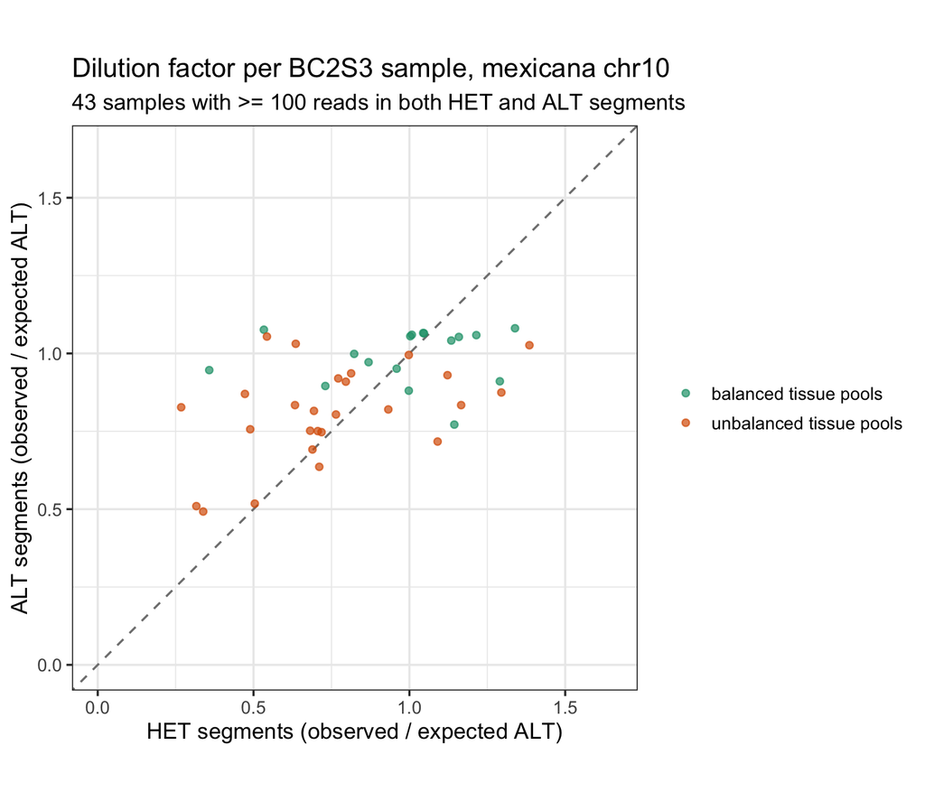

## What it shows

- **Balanced families:** ALT factor near 1 (median 1), HET factor spread by segregation; the two are unrelated (r = 0.09).
- **Unbalanced families:** both factors lower (medians 0.63 and 0.83) and moving together (r = 0.47). 4 samples sit on the diagonal with an ALT factor below 0.65: diluted pools.
- **REF background is the same** in both (1.2 %). Tissue from another donor family would raise it; B73 or recurrent-parent tissue would not. So the dilution, where present, is B73-like.

## Limits

- Only 43 of 153 samples have both factors: many samples carry no ALT segment on chr10.
- Selection is not tested here; it needs the deficit per region across families (recurring low windows, stronger in ALT than in HET segments).
- One chromosome, one taxon.